# Analysis of the Distribution of Salaries on NBA Teams Over Time and in Relation to Wins

Introduction

- Context
- My Hypotheses
- More open-ended questions to explore

Import

Part 1 - Data Retrieval and Wrangling

- Retrieve base HTML which contains all the years
- Get the years from base HTML, save to JSON, and save soup and data
- Crawl for each past year and save HTML
- Read the teams and team salary from each saved year soup and add to JSON object
- Crawl each team in each year and save HTML
- Get the players' salaries from each team from each year and add to JSON object
- Adding win data
  - Fetch the raw standings data from unofficial nba api
  - Extracting and normalizing the win data for each team
  - Add win data to JSON

Part 2 - Transformation and Analysis

- Load salary data into pandas
- Validating Salary Data
- Cleaning Salary Data
- Transforming Data
- Find relative standard deviation, or coefficient of variation, and add to each team
- Adding Win Percentages to the DataFrame
- Alternative workflow for data pipeline
- Spot Checking the Data
- Measuring the Distribution of Salaries
- Plotting the League's Average Distribution Over Time
- Relating Wins to Distribution of Salaries
- Correlation of Win Percentage and Relative Standard Deviation
  - Observed Data
  - Random Data
- Further Exploration
- Correlation Conclusions
- Measuring Correlation Over Time

Conclusions

- Results
- Suggestions for future direction
- What I would do differently

Appendix

- Data sources
- Git history

# Introduction top

### Context top

By 2010 Lebron James was considered by many the best basketball player in the NBA and a once-in-a-lifetime talent. Time since 2010 has affirmed these judgements. 2010 is special because that is the year he infamously declared he ["would take his talents to South Beach and join the Miami Heat."](https://www.youtube.com/watch?v=RTeCc8jy7FI). As a free-agent he was able to sign a new contract with any team. He joined other superstar free-agents Dwayne Wade and Chris Bosh to form what is now known as "The Big 3."

This moment was special not only because these 3 players were so good, but because normally the salary cap prohibits too many stars accumulating on one team. Not only did these 3 players all take less money than they could get elsewhere, but Miami was able to get rid of their bad contracts from the previous year. This was a rare opportunity.

While this strategy saw succes, with Miami winning 2 championships before Lebron left in 2015, it was not without drawbacks. Outside of the big 3 the heat had a few decent players, and some other one-dimensional players. These one-dimensional players only contributed to 3-point shooting, or defense, etc. In other words, this very succesful team had lots of bad players.

Other teams emulated this model such as Brooklyn in '14 with Kevin Garnet, Paul Peirce , Deron William, and Joe Johnson, who did very poorly. We also saw the same dynamic (probably even morese) in Cleveland when Lebron returned there after leaving Miami.

### My hypotheses top

- Team's salaries are more unevenly distributed in 2021 than the mid 90's (when I started folliwing the NBA). (Jump to results)
  - This trend coincides with Lebron's move to Miami in 2011 (Jump to results)

### More open-ended questions to explore top

- Does this strategy work? If this is truly a trend, one simple explanation is that it's effective. (Jump to results)
  - Has this strategy's effectiveness been consistent or changed over time? (Jump to results)
- Do some of the historically signifant teams share similarities in their distribution of salaries? (Jump to results)

# Import top

All imports for the notebook are handled here.

```python
%matplotlib inline

# data retrieval
from bs4 import BeautifulSoup
import requests
import json
import os
from time import sleep
from nba_api.stats.endpoints import leaguestandings
import datetime as dt

# analysis
import pandas as pd
import numpy as np
from scipy.stats import variation
from scipy.stats import shapiro
from scipy.stats import pearsonr
from scipy.stats import truncnorm
from scipy.stats import linregress
import matplotlib.pyplot as plt
import random
import warnings
warnings.simplefilter(action='ignore', category=pd.errors.PerformanceWarning)
```

# PART 1 - Data Retrieval and Wrangling top

This section retrieves the data from external sources, saves them locally, then loads them to build a JSON object. This is not meant to be run if we already have the data, which we do. Re-running these steps takes considerable time because I save 900+ html files to avoid having to revist them in consideration of the site owner. These files have not been shared due to the assignment's file size restrictions (10MB). These steps should still work fine but know that they are not necessary to run because I have provided the JSON object that all this scraping and saving results in.

## Retrieve base HTML which contains all the years top

I am getting all of my salary data from https://hoopshype.com/salaries/, which has no policy against scraping. I was tempted to use https://www.basketball-reference.com which is the gold-standard for nba data but they [explicitly prohibit scraping](https://www.sports-reference.com/data_use.html).

I made functions for getting, saving and loading soup objects that we will use whenever we scrape and parse data. By saving the soup to file we will avoid having to re-scrape the site to get the page into memory. Putting sleep() in getSoup() ensures we make requests too quickly later when we are scraping lots of different urls and retrying requests.

```python
def getSoup(url):
    page = requests.get(url)
    sleep(0.6)
    return BeautifulSoup(page.content, 'html.parser')

def saveSoup(soup, filePath):
    path = filePath.rpartition('/')[0] # == 'parent/child' for 'parent/child/file.txt'

    if not os.path.exists(path):
        os.makedirs(path)

    with open(filePath, 'w', encoding='utf-8') as fp:
            fp.write(str(soup))

def loadSoup(filePath):
    with open(filePath, 'rb') as html:
        return BeautifulSoup(html)
```

Requests if html file does not exist locally, or if forced.

```python
baseDir = 'data/raw/soups/base.html'
force = False

if not os.path.exists(baseDir) or force:
    print(f'{baseDir} doesn\'t exist.\nRequesting and saving. ')
    soup = getSoup('https://hoopshype.com/salaries')
    saveSoup(soup, baseDir)
else:
    print("File already exists. Set force to 'True' if you want to re-request.")
```

```
File already exists. Set force to 'True' if you want to re-request.
```

The website displays the year in a format like 2019/20 but the URL uses the format 2019-2020. So before saving the date we will transform it to this new format. We will also need to reformat it to the long version later as well.

```python
def toShortYear(longYear):
    '''converts from format like 2019-2020 to format like 2019-20'''
    return f'{longYear[:5]}{longYear[7:]}'

def toLongYear(shortYear):
    '''converts from format like 2019/20 to format like 2019-2020'''
    longYear = shortYear.replace("/","-")

    firstTwo = shortYear[:2] #20 from 2019
    lastTwo = shortYear[2:4] #19 from 2019

    indexToInsert = longYear.find("-") + 1

    if lastTwo != '99':
        longYear = longYear[:indexToInsert] + firstTwo  + longYear[indexToInsert:]
    else:
        newFirstTwo = str(int(firstTwo) + 1)
        longYear = longYear[:indexToInsert] + newFirstTwo  + longYear[indexToInsert:]

    return longYear
```

## Get the years from base HTML, save to JSON, and save soup and data top

As we parse data at the different levels (years, teams of years, players of teams) we will save to our main data object. I am using. To make this easier I am making save and load functions. I will save to a work-in-progress JSON object until it is finalized to avoid saving over our complete data object later by executing an earlier cell.

```python
def saveDataWIP(data):
    '''Use this function for saving to JSON while building the object'''
    with open('data/nbaSalaryData-WIP.json', 'w') as fp:
        json.dump(data, fp, indent=4)

def loadDataWIP():
    with open('data/nbaSalaryData-WIP.json', 'r') as fp:
        return json.load(fp)
```

First we find all the year strings from the base html. We use this to start our JSON object and will refer back to it to continue scraping.

```python
#first two links are duplicate
soup = loadSoup('data/raw/soups/base.html')
yearLinks = soup.find('li', class_='all').find_all('a')[1:]
yearStrings = []

# strip
for year in yearLinks:
    txt = toLongYear(year.text.strip())
    yearStrings.append(txt)
print(f"Found {len(yearStrings)} years")

#sort from low year to high year, and fill dict
yearStrings.sort()
currentYear = yearStrings[-1]

#start data object and save
nbaSalaryData = dict.fromkeys(yearStrings)
saveDataWIP(nbaSalaryData)

saveSoup(soup, f'data/raw/soups/{currentYear}/{currentYear}.html')
```

```
Found 31 years
```

## Crawl for each past year and save HTML top

I chose to save the HTML pages and wait between requests because we will be making a request for each year. I do not want to make many requests in quick succession nor make the same requests again in the future unless I expect that the data has actually changed.

Occasionally scraping a year works but the teams don't populate in the table. To deal with this, I check the number of teams in the table. When the table of teams doens't populate I retry the request a limited number of times, and print the year that has failed with the number of retry attempts. If all retries fail they have to be manually scraped.

I first check if the soup exists before making any new requests.

```python
def soupIsValid(soup):
    # detects if table is not populated correctly
    return len(soup.find_all('td', class_='name')) > 1
```

```python
nbaSalaryData = loadDataWIP()
force = False
existLocally = []

# past years only because current year was saved earlier
pastYears = list(nbaSalaryData.keys())[:-1]

for year in pastYears:
    soupDir = f'data/raw/soups/{year}/{year}.html'

    if not os.path.exists(soupDir) or force:
        print(f"Getting soup for {year}")
        soup = getSoup(f'https://hoopshype.com/salaries/{year}/')

        if not soupIsValid(soup):
            print(f'soup retreived for year {year} is not valid')
            for n in range(5):
                print(f'retrying {n}')
                soup = getSoup(url)
        #save soup to .html file
        saveSoup(soup, soupDir)
    else:
        existLocally.append(year)

if len(existLocally) > 0:
    print(f"Did not make requests for {len(existLocally)} " \
        f"years because they were found locally: \n{existLocally}")
```

```
Did not make requests for 30 years because they were found locally:
['1990-1991', '1991-1992', '1992-1993', '1993-1994', '1994-1995', '1995-1996', '1996-1997', '1997-1998', '1998-1999', '1999-2000', '2000-2001', '2001-2002', '2002-2003', '2003-2004', '2004-2005', '2005-2006', '2006-2007', '2007-2008', '2008-2009', '2009-2010', '2010-2011', '2011-2012', '2012-2013', …
```

## Read the teams and team salary from each saved year soup and add to JSON object top

```python
# load data and soup files
nbaSalaryData = loadDataWIP()
yearFiles = ([f'{x[0]}/{x[2][0]}' for x in list(os.walk("data/raw/soups"))[1:]])
yearFiles
# add teams to year data for each year
for f in yearFiles:
    soup = loadSoup(f)
    year = f.split("/")[-1].split('.')[0]

    # assign empty object so we can assign object with 'nbaSalaryData[year][name]' later
    # otherwise 'nbaSalaryData[year][name]' results in NoneType error (because nbaSalaryData[year]=None)
    nbaSalaryData[year] = {}

    #filter for elements containing the team names
    options = soup.find_all('td', class_='name')
    options = options[1:] # get rid of first elemented which does't contain a team

    #parse team data
    for o in options:
        #find team name and salary
        teamTags = o.find_all('a')

        for t in teamTags:
            name = t.text.strip()
            salary = t.parent.find_next_sibling('td').text.strip()
            url = t.get('href')
            nbaSalaryData[year][name] = {"salary": salary, "players": {}, "url": url}

# save
saveDataWIP(nbaSalaryData)
print(f"Team information added to WIP JSON")
```

```
Team information added to WIP JSON
```

## Crawl each team in each year and save HTML top

These are the last soup objects we will need to collect.

This step will take a while (about 20 minutes in my experience) because there are 31 years and at least 28 teams pear year and `getSoup()` waits 0.6 seconds per request. We could theoretically shorten this by reducing the pause but this might negatively impact the website and our ability to scrape from it. Instead of scraping, I recommnend downloading [an archive of the soups from my google drive](https://drive.google.com/file/d/1hBgRl81I3zKut54diDXfmsom1yscSLT7/view?usp=sharing) and unzipping the contents to `data/raw.` If the pages exist locally then they are not rescraped. The cell can be run but it will only check to confirm the files exist locally.

```python
nbaSalaryData = loadDataWIP()
```

```python
force = False
existLocally = 0
total = 0

for year in nbaSalaryData.keys():
    for team in nbaSalaryData[year]:
        soupDir = f'data/raw/soups/{year}/{team}.html'

        if not os.path.exists(soupDir) or force:
            print(f"Saving soup for {year}: {team}")
            soup = getSoup(nbaSalaryData[year][team]['url'])
            saveSoup(soup, f'data/raw/soups/{year}/{team}.html')
        else:
            existLocally += 1
        total += 1

if existLocally > 0:
    print(f"Did not make requests for {existLocally}/{total} teams")
```

```
Did not make requests for 906/906 teams
```

The soup object file structure now looks something like this:

```
data
 |_raw
 |  |_soups
 |     |_base.html           #homepage. used to find years
 |     |_1990-1991
 |     |   |_1990-1991.html  #page containing teams for 1990-1991
 |     |   |_Atlanta.html    #page containing Atlana
 |     |   |_Boston.html
 |     |   ...
 |     |   |_Washington
 |     |_1991-1992
 |     ...
 |     |_2020-2021
 |_nbaSalaryData-WIP.json
```

## Get the players' salaries from each team from each year and add to JSON object top

Checks if players are already loaded into JSON before saving. This can be overriden by setting `force` to `True` to save over existing player salary information. This step is slow, taking roughly 30 seconds to run.

```python
nbaSalaryData = loadDataWIP()
```

```python
force = False
existJson = []
addedTo = 0

# list of paths to each year
yearPaths = [x[0] for x in os.walk("data/raw/soups")][1:]

for y in yearPaths:
    year = y.split("\\")[1]
    #list of team files in each year
    teamFiles = list(os.walk(y))[0][2][1:]

    for tf in teamFiles:
        team = tf.split(".")[0]

        if not nbaSalaryData[year][team]["players"] or force:
            soup = loadSoup(f"{y}\\{tf}")

            #filter for elements containing the team names
            options = soup.find('table', class_='hh-salaries-team-table').find_all('td', class_="name")

            #parse player data
            for o in options:
                #find player name and salary
                playerTags = o.find_all('a')

                for p in playerTags:
                    name = p.text.strip()
                    salary = p.parent.find_next_sibling('td').text.strip()
                    nbaSalaryData[year][team]['players'][name] = salary
            addedTo += 1
        else:
            existJson.append(f"{year}: {team}")
# save
saveDataWIP(nbaSalaryData)

if len(existJson) > 0:
    print(f"Skipped {len(existJson)} teams because salary information was already found: \n {existJson}")
else:
    print(f"{addedTo} team's player salary information added to WIP JSON ")
```

```
906 team's player salary information added to WIP JSON
```

This salary data can be accessed like so:

```python
nbaSalaryData["2014-2015"]["Orlando"]["players"]
```

```
{'Channing Frye': '$8,579,088',
 'Al Harrington': '$7,609,800',
 'Glen Davis': '$6,600,000',
 'Victor Oladipo': '$4,978,200',
 'Ben Gordon': '$4,500,000',
 'Aaron Gordon': '$3,992,040',
 'Nikola Vucevic': '$2,902,757',
 'Luke Ridnour': '$2,750,000',
 'Tobias Harris': '$2,511,432',
 'Elfrid Payton': '$2,397,840',
 'Jameer Nelson': '$2,000,000',
 'Moe Harkless': '$1,887,840',
 'Anthony Randolph': '$1,825,359',
 'Andrew Nicholson': '$1,545,840',
 'Evan Fournier': '$1,483,920',
 'Willie Green': '$1,448,490',
 "Kyle O'Quinn": '$915,243',
 'Devyn Marble': '$884,879',
 'Dewayne Dedmon': '$816,482'}
```

## Adding win data top

### Fetch the raw standings data from unofficial nba api top

Checks if it exists locally before requesting from the [unofficial nba api](https://github.com/swar/nba_api). Each request sleeps for 0.6 seconds but there are only 31 requests so the overall time is not that long. Saves after retrieving. Can be forced by setting `force` to `True`.

```python
force = False
rsDir = 'data/raw/standings.json'
seasons = [toShortYear(k) for k in nbaSalaryData.keys()]

# gets win data from nba.com api unless found locally
if not os.path.isfile(rsDir) or force:
    print(f'Requesting data starting in {seasons[0]} and ending in {seasons[-1]}')

    rawStandingsData = {"resourceSets": []}

    # get data for all seasons
    for s in seasons:
        print(f'Requesting data for {s}')
        standing = json.loads(leaguestandings.LeagueStandings(season=s).get_json())
        rawStandingsData["resourceSets"].append(standing)
        sleep(0.6)

    with open(rsDir, 'w') as fp:
        json.dump(rawStandingsData, fp, indent=4)

else:
    print("Raw standings data already exists locally.")
```

```
Raw standings data already exists locally.
```

### Extracting and normalizing the win data for each team top

The teams in `rawStandingsData` are organized differently than our JSON data. In order to combine this with our salary data we need to normalize the cities. For example, this data source includes `Seattle` and `Oklahoma City,` which our previous data source simplifies to `Oklahoma City` (the Seattle team moved to Oklahoma City in 2008). We don't care about preserving these distinctions so the simplified version that we already have works better. Other normalizations include converted the two Los Angeles teams (Lakers, Clippers) to `LA Lakers` and `LA Clippers` to match the `nbaSalaryData` format. This transformation happens after we access the team name and city data from `rawStandingsData`.

We can validate that the team names have been normalized by printing all the teams in from our win data and comparing it to the teams in our JSON object. This is defined in `printInvalidTeams()` and utilized called later to print out the number of teams (if any) that differ. They should be 0 if they have all been converted. The following functions are used in normalizing the data from the new source:

```python
def normalizeCity(originalCity, teamName=None):
    cityMap = {
        "New Jersey": "Brooklyn",
        "Vancouver": "Memphis",
        "New Orleans/Oklahoma City": "New Orleans",
        "Seattle": "Oklahoma City",
        "LA": "Los Angeles"
}

    c = originalCity
    if c in cityMap:
        c = cityMap[originalCity]
    if c == "Los Angeles":
        c = whichLA(teamName)
    return c

def whichLA(teamName):
    if teamName == "Lakers":
        return "LA Lakers"
    elif teamName == "Clippers":
        return "LA Clippers"
    else:
        raise Exception('teamName did not match expected values')

def printInvalidTeams(winData, nbaSalaryData):
    teams = set()

    for year in list(winData.keys()):
        list1 = list(nbaSalaryData[year].keys())
        list2 = list(winData[year].keys())
        diff = list(set(list1) - set(list2))
        for d in diff:
            teams.add(d)

    if len(teams)>0:
        print(f"{len(teams)} team(s) in requested data but not in nbaSalaryData:")
        print(teams)
    else:
        print("No teams in requested data that don't exist in nbaSalaryData")
```

To get the win data from our new source we will use `getWinData()`. This traverses the `rawStandingsData` and returns a winData object like so:

```
   {
       '1990-1991':
           {
               'Portland': 0.768,
               'Chicago': 0.744,
               ...
           },
        ...
   }
```

This is also where we use `normalizeCity()` to map this data source's naming scheme to our json object's naming scheme.

```python
def getWinData(rawStandingsData):
    winData = {}

    #get indexes for categories we need
    rawStandingsDataHeaders = rawStandingsData["resourceSets"][0]["resultSets"][0]["headers"]
    iCity = rawStandingsDataHeaders.index("TeamCity")
    iName = rawStandingsDataHeaders.index("TeamName")
    iWinPct = rawStandingsDataHeaders.index("WinPCT")

    for year in rawStandingsData["resourceSets"]:
        y = toLongYear(year["parameters"]["SeasonYear"])
        winData[y] = {}
        for team in year["resultSets"][0]["rowSet"]:
            t = normalizeCity(team[iCity], team[iName])
            winData[y][t] = team[iWinPct]

    return winData
```

### Add win data to JSON top

The following functions are used to add the data to our json object and to save it. I also created a new `loadData()` function to accompany `saveData()` because `saveData()` saves our now finalized JSON to a different location.

```python
def addWinDataToJson(winData, nbaSalaryData):
    for year in winData.keys():
        for team in winData[year].keys():
            nbaSalaryData[year][team]["winPct"] = winData[year][team]

    return nbaSalaryData

def saveData(nbaSalaryData):
    with open('data/nbaSalaryData.json', 'w') as fp:
        json.dump(nbaSalaryData, fp, indent=4)

def loadData():
    with open('data/nbaSalaryData.json', 'r') as fp:
        return json.load(fp)
```

This cell utilizes the above functions to go through all the years in our raw data set, normalizes the team city names, print if the cities match, and adds it to our JSON unless it has already been added. This can be overriden by setting `force` to `True`.

```python
force = False

# open raw standings data
with open(rsDir, 'r') as fp:
    rawStandingsData = json.load(fp)

# get win pct for each team and add to json object
if not os.path.exists('data/nbaSalaryData.json') or force:
    nbaSalaryData = loadDataWIP()
    winData = getWinData(rawStandingsData)
    printInvalidTeams(winData, nbaSalaryData)
    nbaSalaryData = addWinDataToJson(winData, nbaSalaryData)
    saveData(nbaSalaryData)
    print("Saved winPct to nbaSalary.json")
else:
    print("winPct already added to nbaSalaryData.json")
```

```
winPct already added to nbaSalaryData.json
```

Now that we are done building our WIP json object we can delete the file.

```python
if os.path.exists('data/nbaSalaryData-WIP.json'):
    os.remove('data/nbaSalaryData-WIP.json')
    print("removed json")
else:
    print("json not found")
```

```
removed json
```

Now we can access a team's win percentage for a year like so:

```python
nbaSalaryData = loadData()
nbaSalaryData["2011-2012"]["Miami"]["winPct"] # returns 0.697
```

```
0.697
```

# Part 2 - Transformation and Analysis top

## Load salary data into pandas top

Before we can explore our results we need to load our data into pandas to clean, transform, and ultimately draw our conclusions from. I have done so cell-by-cell because it is easier to narrate the changes step-by-step, but an alternative (probably much better real-world) method is displayed here after the data has been loaded, clean and transformed to our need.

```python
nbaSalaryData = loadData()

df = pd.Series({
    (i,j,m): nbaSalaryData[i][j][k][m]
    for i in nbaSalaryData
    for j in nbaSalaryData[i]
    for k in ['players']
    for m in nbaSalaryData[i][j][k]
}).to_frame('salary').rename_axis('year team player'.split())
df
```

| year | team | player | salary |
| --- | --- | --- | --- |
| 1990-1991 | Cleveland | Hot Rod Williams | $3,785,000 |
|  |  | Danny Ferry | $2,640,000 |
|  |  | Mark Price | $1,400,000 |
|  |  | Brad Daugherty | $1,320,000 |
|  |  | Larry Nance | $1,260,000 |
| ... | ... | ... | ... |
| 2020-2021 | New York | Ignas Brazdeikis | $1,517,981 |
|  |  | Wayne Ellington | $1,000,000 |
|  |  | Taj Gibson | $1,000,000 |
|  |  | Jared Harper | $79,568 |
|  |  | Andrew White | $25,000 |

14446 rows × 1 columns

## Validating Salary Data top

Before using our data we should check for empty string or null values. We can see how many of these values there are (and there location) using `np.where()` and `pd.isnull()` like so:

```python
def printNullorEmptyStr(df):
    # null values
    isnull = np.where(pd.isnull(df))
    print(f"There are {len(isnull[0])} null salaries" )

    # empty values
    empty = np.where(df.applymap(lambda x: x == ''))
    print(f"There are {len(empty[0])} empty salaries" )
```

```python
printNullorEmptyStr(df)
```

```
There are 0 null salaries
There are 28 empty salaries
```

## Cleaning Salary Data top

To deal with these, we will convert the empty salaries to null and drop all null objects.

```python
df2 = df.replace('', np.nan)
df2 = df2.dropna()
```

Now we can check for null or empty string values again with `printNullorEmptyStr()` and see that they are removed.

```python
printNullorEmptyStr(df2)
```

```
There are 0 null salaries
There are 0 empty salaries
```

We will also need to convert our currency strings to floats which we cause use regex for.

```python
df3 = df2.replace('[\$,]','',regex=True).astype(float)
df3.head()
```

| year | team | player | salary |
| --- | --- | --- | --- |
| 1990-1991 | Cleveland | Hot Rod Williams | 3785000.0 |
|  |  | Danny Ferry | 2640000.0 |
|  |  | Mark Price | 1400000.0 |
|  |  | Brad Daugherty | 1320000.0 |
|  |  | Larry Nance | 1260000.0 |

Now our data has been cleaned.

## Transforming Data top

### Find relative standard deviation, or coefficient of variation, and add to each team top

Now that I have the salary information cleaned and loaded into the datafram I can determine the coefficient of variation from the player salaries on each team for each year. The coefficient of variation is also known as the relative standard deviation and serves of a good measure of how disparite salaries are on a team. High means there is a big disparity and low means there is less disparity.If all salaries were equal the relative standard deviation would be 0. I explain why I am using this metric in greater detail in this section.

Here is an example of how it can be applied to a single team using `variation` that we imported from `scipy.stats`:

```python
# sorting first speeds up the following .apply method
# and avoids an ipython warning about performance
df4 = df3.sort_index()
df4.loc[('1990-1991', 'Atlanta')].apply(variation) # 0.716301
```

```
salary    0.716301
dtype: float64
```

Now we will use `apply()` to get the relative standard deviation for all teams for all years. We will save this over the players and salary as we no longer need them.

```python
df5 = (df4.groupby(["year", "team"])
       .apply(variation)
       .astype(float)
       .to_frame()
       .rename(columns={0:'salary rsd'}))
df5
```

| year | team | salary rsd |
| --- | --- | --- |
| 1990-1991 | Atlanta | 0.716301 |
|  | Boston | 0.817674 |
|  | Brooklyn | 0.709815 |
|  | Charlotte | 0.612866 |
|  | Chicago | 0.722554 |
| ... | ... | ... |
| 2020-2021 | Sacramento | 1.110634 |
|  | San Antonio | 1.041250 |
|  | Toronto | 1.338505 |
|  | Utah | 1.177966 |
|  | Washington | 1.400230 |

906 rows × 1 columns

Although the sample size is small, the above output suggests we may see a differences between the distributions of salaries over time.

### Adding Win Percentages to the DataFrame top

This is the last thing we need to add to the dataframe before we can start analyzing. This is accomplished by making a new dataframe from our JSON object that has the same indices, length, and order of our original dataframe. Then we can simply add the values of our new dataframe to our existing one.

```python
def getWinTuples(nbaSalaryData):
    data = []
    for year in nbaSalaryData.keys():
        for team in nbaSalaryData[year]:
            data.append((year, team, nbaSalaryData[year][team]['winPct']))
    return data
```

```python
nbaSalaryData = loadData()
data = getWinTuples(nbaSalaryData)
dfTemp = (pd.DataFrame(data, columns=["year", "team", "win percentage"])
     .set_index(["year", "team"])
     .sort_index())
df5["win percentage"] = dfTemp.values
df5
```

| year | team | salary rsd | win percentage |
| --- | --- | --- | --- |
| 1990-1991 | Atlanta | 0.716301 | 0.524 |
|  | Boston | 0.817674 | 0.683 |
|  | Brooklyn | 0.709815 | 0.317 |
|  | Charlotte | 0.612866 | 0.317 |
|  | Chicago | 0.722554 | 0.744 |
| ... | ... | ... | ... |
| 2020-2021 | Sacramento | 1.110634 | 0.429 |
|  | San Antonio | 1.041250 | 0.333 |
|  | Toronto | 1.338505 | 0.167 |
|  | Utah | 1.177966 | 0.667 |
|  | Washington | 1.400230 | 0.286 |

906 rows × 2 columns

Now we have everything we need to analyze salary distribution over time and in relation to win percentage.

## Alternative workflow for data pipeline top

Instead of going through cell-by-cell as I did above we could use a workflow similar to the one demo'd in [Vincent D. Warmerdam's 2019 PyData talk entitled](https://www.youtube.com/watch?v=yXGCKqo5cEY&t=1268s). This template takes advantage of pandas' `pipe` to chain together series of functions on a dataframe. I would prefer this alternative in most cases, but I wanted to keep things procedural for this assignment since it allows me to explain the process better.

We can define all of our cleaning, transforming, adding, as well as removing outliers or any other such tasks to prepare our dataframe before analysis. In this case we refer back to our original dataframe, `df`, before processing it. As you can see, the out matches our finalized dataframe above.

```python
def log(f):
    def wrapper(df, *args, **kwargs):
        start = dt.datetime.now()
        result = f(df, *args, **kwargs)
        stop = dt.datetime.now()
        print(f'{f.__name__}:\n  runtime={stop - start}, end shape={result.shape}')
        return result
    return wrapper

@log
def startPipeline(df):
    return df.copy()

@log
def clean(df):
    # replace empty str with null and remove null
    df.replace('', np.nan, inplace=True)
    df.dropna(inplace=True)
    # convert salary str to float
    df = df.replace('[\$,]','',regex=True).astype(float)
    return df

@log
def transform(df):
    df = (df.groupby(["year", "team"])
           .apply(variation)
           .astype(float)
           .to_frame()
           .rename(columns={0:'salary rsd'}))
    return df

@log
def add(df):
    nbaSalaryData = loadData()
    data = []
    for year in nbaSalaryData.keys():
        for team in nbaSalaryData[year]:
            data.append((year, team, nbaSalaryData[year][team]['winPct']))
    dfTemp = (pd.DataFrame(data, columns=["year", "team", "win percentage"])
     .set_index(["year", "team"])
     .sort_index())
    df["win percentage"] = dfTemp.values
    return df


@log
def removeOutliers(df):
    return df

dfPipe = (df
 .pipe(startPipeline)
 .pipe(clean)
 .pipe(transform)
 .pipe(add)
 .pipe(removeOutliers))
dfPipe
```

```
startPipeline:
  runtime=0:00:00, end shape=(14446, 1)
clean:
  runtime=0:00:00.033961, end shape=(14418, 1)
transform:
  runtime=0:00:00.133006, end shape=(906, 1)
add:
  runtime=0:00:00.014997, end shape=(906, 2)
removeOutliers:
  runtime=0:00:00, end shape=(906, 2)
```

| year | team | salary rsd | win percentage |
| --- | --- | --- | --- |
| 1990-1991 | Atlanta | 0.716301 | 0.524 |
|  | Boston | 0.817674 | 0.683 |
|  | Brooklyn | 0.709815 | 0.317 |
|  | Charlotte | 0.612866 | 0.317 |
|  | Chicago | 0.722554 | 0.744 |
| ... | ... | ... | ... |
| 2020-2021 | Sacramento | 1.110634 | 0.429 |
|  | San Antonio | 1.041250 | 0.333 |
|  | Toronto | 1.338505 | 0.167 |
|  | Utah | 1.177966 | 0.667 |
|  | Washington | 1.400230 | 0.286 |

906 rows × 2 columns

## Spot Checking the Data top

Before looking at the data as a whole I will spot-check a few notable teams that I'm familiar with and see how they compare.

```python
def playersAndSalaries(year, team):
    temp = df3.loc[(year, team)]
    players = temp.index.values
    salaries = temp["salary"].replace('[\$,]','',regex=True).astype(float).tolist()
    # sort salaries in ascending and mirror changes in labels
    salaries, players = zip(*sorted(zip(salaries, players), reverse=True))
    return list(players), list(salaries)
```

```python
def plotTeamSalaries(year, team):
    labels, salaries = playersAndSalaries(year, team)

    print(f"{team}, {year}, {variation(salaries)}")
    plt.rcParams['figure.figsize'] = [15, 8]
    plt.pie(salaries, labels=labels)
    plt.show()
```

```
Chicago, 1992-1993, 0.8904381641077361
```

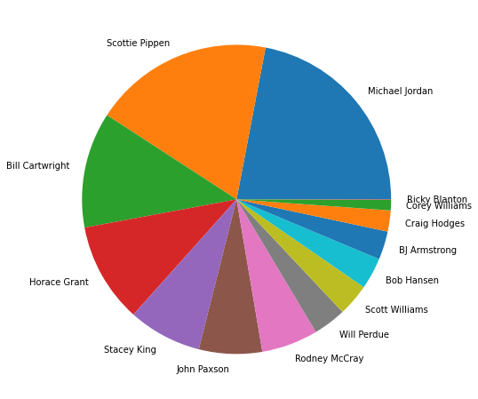

```python
plotTeamSalaries("1992-1993", "Chicago")
```

```
Miami, 2010-2011, 1.342881292618329
```

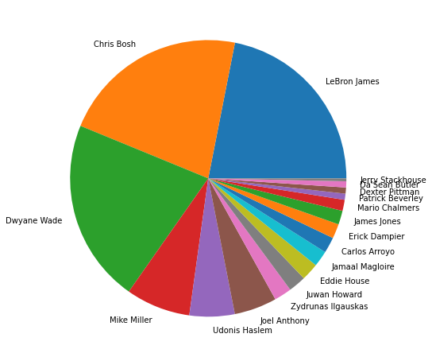

```python
plotTeamSalaries("2010-2011", "Miami")
```

The top 3 players take a larger share of the salary (~66%) then the '93 bulls (~55%) which makes the remaining players share smaller.

```
Golden State, 2015-2016, 0.8776202924585763
```

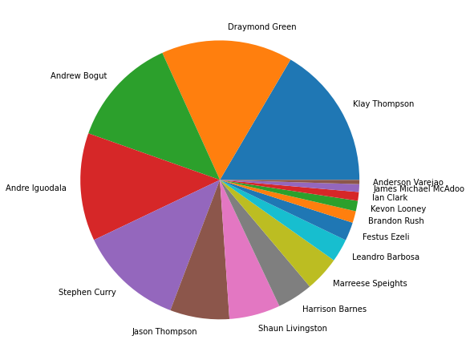

```python
plotTeamSalaries("2015-2016", "Golden State")
```

This looks more more even than the '93 Bulls but this is mostly on the top end. The overall relative standard deviation is 0.87 for the Warriors but the Bulls are only marginally higher at 0.89. This is the distrubution for the NBA team with the highest regular season win percentage in NBA history, winning 73 out of 82 games. However, this is atypical because Stephen Curry was on a very low-paying contract (only 5th highest on his team) due to past performance and injury trouble, despite being the MVP for the 2015-2016 season.

```
LA Lakers, 2019-2020, 1.4848159577370332
```

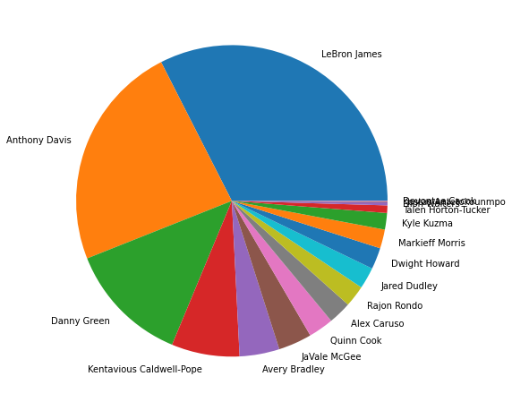

```python
plotTeamSalaries("2019-2020", "LA Lakers")
```

This example is the most extreme of the one's we've checked, with one player taking over 25% of the entire salary cap and the top 2 taking over 50%. If we want to get more specific and see just what % each player gets we can print and graph the share of the total per player.

```python
def sharePerPlayer(year, team):
    players, salaries = playersAndSalaries(year, team)
    shares = [x / sum(salaries) for x in salaries]
    return players, shares

def printSharesPerPlayer(year, team):
    players, shares = sharePerPlayer(year, team)
    ps = list(zip(players, shares))
    for p in ps:
        print(p)
```

```python
printSharesPerPlayer("2019-2020", "LA Lakers")
```

```
('LeBron James', 0.3250238407719033)
('Anthony Davis', 0.23521944853080756)
('Danny Green', 0.1270525070335931)
('Kentavious Caldwell-Pope', 0.07066460269624174)
('Avery Bradley', 0.04138671704125552)
('JaVale McGee', 0.03472768369310302)
('Quinn Cook', 0.026045762769827265)
('Alex Caruso', 0.023875282539008325)
('Rajon Rondo', 0.022266982733734262)
('Jared Dudley', 0.022266982733734262)
('Dwight Howard', 0.022266982733734262)
('Markieff Morris', 0.019620160229538875)
('Kyle Kuzma', 0.017143321055100306)
('Talen Horton-Tucker', 0.007799056384587844)
('Dion Waiters', 0.0032590628857838695)
('Kostas Antetokounmpo', 0.0006908030840232053)
('Devontae Cacok', 0.0006908030840232053)
```

More precisely, we see that Lebron James has 32.5% of the total salary and Anthony Davis has 23.5%, for a total of 56% of the entire salary between the two of them. A bar chart gives us another way to visualize this distribution further:

```python
def plotSalariesPerPlayer(year, team):
    players, salaries = playersAndSalaries(year, team)
    firstNames = [p.split(" ")[0] for p in players]
    plt.bar(firstNames, salaries)
```

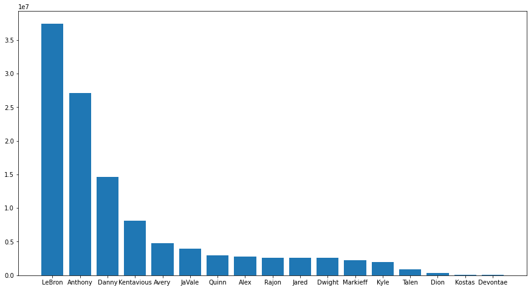

```python
plotSalariesPerPlayer("2019-2020", "LA Lakers")
```

Here you can pick a team at random to generate the bar char and pie graph for, or specify a team and/or year yourself.

```python
def getRandYear():
    years = set(df.index.get_level_values('year'))
    return random.choice(list(years))

def getRandTeamForYear(year):
    teams = set(df.loc[year].index.get_level_values('team'))
    return random.choice(list(teams))
```

```python
def allPlotsRandom():
    year = getRandYear()
    team = getRandTeamForYear(year)
    plotTeamSalaries(year, team)
    plotSalariesPerPlayer(year, team)
```

```
Utah, 2007-2008, 0.9160511680320536
```

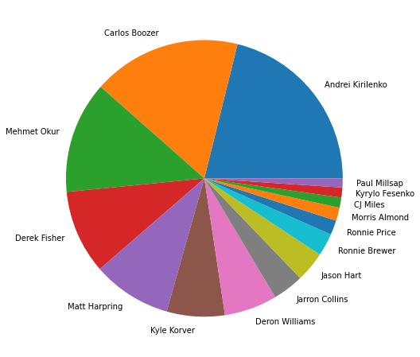

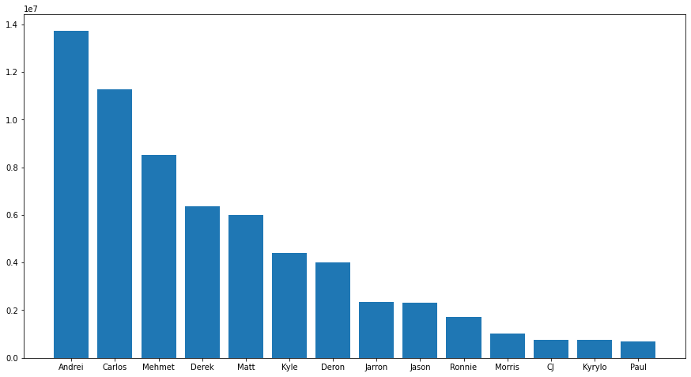

```python
allPlotsRandom()
```

### Spot-checking conclusions top

We can begin to answer one of our more open-ended questions: **Do some of the historically signifant teams share similarities in their distribution of salaries?**

Something else interesting to look at could be the distributions of salaries for all the teams that an individual player was on, namely Lebron. It seems like Lebron, and likely other players, may tend to be on teams with a similar salary distribution. We can't attribute this entirely to ability, as we see that Michael Jordan's team (still considered by most to be the greatest player of all-time) is not similar.

## Measuring the Distribution of Salaries top

Initially I decided to use the standard deviation to measure how salaries are distributed. The standard deviation represents the degree to which salaries on a team deviate from the mean salary. A larger standard deviation means players salaries are distributed less evenly. However, since total salaries have risen a lot since 1990, the average standard deviation will increase over time simply due to salary increases. This is not what we are interested in. This is why I decided to use the [relative standard deviation, or coefficient of variation](https://en.wikipedia.org/wiki/Coefficient_of_variation), which is the standard deviation divided by the mean. This will normalize our salaries so that they can be effectively compared across different periods.

## Plotting the League's Average Distribution Over Time top

We can use a line chart to visualize the difference in average relative standard deviation over time.

```python
def yearsAndAvgRsds(df):
    years = list(set(df.index.get_level_values(0)))
    years.sort()
    rsds = df.groupby('year')['salary rsd'].mean().values
    return years, rsds
```

```python
def plotRsdOverTime(df, team=None):
    temp = df
    # change df if team defined
    if team and team in df.index.levels[1]:
        temp = temp.xs(team, level=1, drop_level=False)
    years, rsds = yearsAndAvgRsds(temp)

    #shorten to start year for graph readability
    years = [y.split("-")[0] for y in years]

    #plot configuration
    title = "Average Relative Standard Deviation of over Time"
    if team:
        title = title + " for " + team
    plt.title(title)
    plt.rcParams['figure.figsize'] = [15, 8]
    plt.plot(years, rsds)
    plt.xlabel("Year")
    plt.ylabel("Average Relative Std. Deviation")
    plt.grid(True)
    plt.show
```

The year shown on the x-axis below is shortened to the the season's start year for legibility. So '1990' represents the 1990-1991 season. The average relative standard deviation is the average for all teams in the league for the given year. This should either confirm or deny our main hypothesis: **Team's salaries are less evenly distributed in 2021 than the mid 90's (when I started folliwing the NBA).**

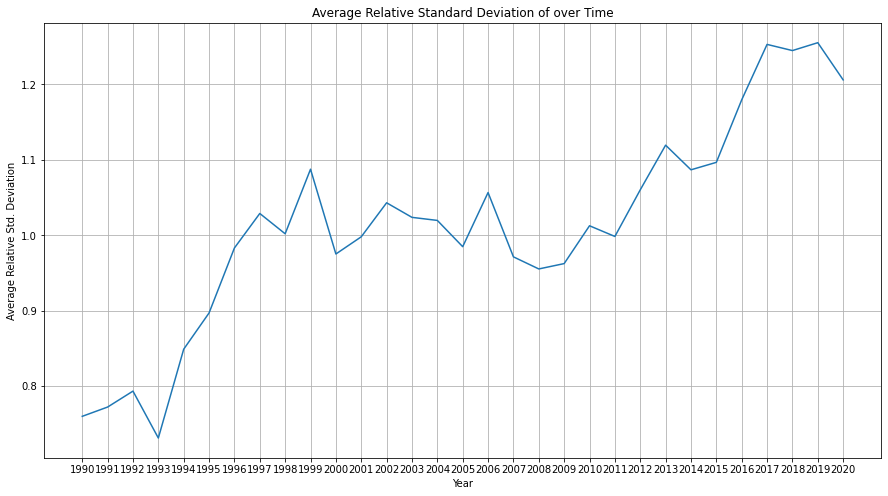

```python
plotRsdOverTime(df5)
```

This graph shows that the original hypothesis was correct - the difference between salaries on teams is getting larger over time. Interestingly, the more recent upwards trend starts aroud the formation of "The Big 3" (Lebron James, Chris Bosh, and Dwayne Wade) in Miami in 2011.This confirms our follow-up hypothesis that **this trend coincides with Lebron's move to Miami in 2011**.

In addition, RSD increased a lot between 1993 and 1999 before leveling off until about 2012 where we see the hypothesized trend upward to the present year (where it may be leveling off again). It would be interesting to get earlier data and see if there is a plateau leading up to 1993. Similarly, it will be interesting going forward to see if the past few years continue to stay within the same range or breakout in either direction.

We can also plot a specifi team's relative standard deviation over time for one of the listed teams like so:

```python
df.index.levels[1]
```

```
Index(['Atlanta', 'Boston', 'Brooklyn', 'Charlotte', 'Chicago', 'Cleveland',
       'Dallas', 'Denver', 'Detroit', 'Golden State', 'Houston', 'Indiana',
       'LA Clippers', 'LA Lakers', 'Memphis', 'Miami', 'Milwaukee',
       'Minnesota', 'New Orleans', 'New York', 'Oklahoma City', 'Orlando',
       'Philadelphia', 'Phoenix', 'Portland', 'Sacramento', 'San Antonio',
       'Toronto', 'Utah', 'Washington'],
      dtype='object', name='team')
```

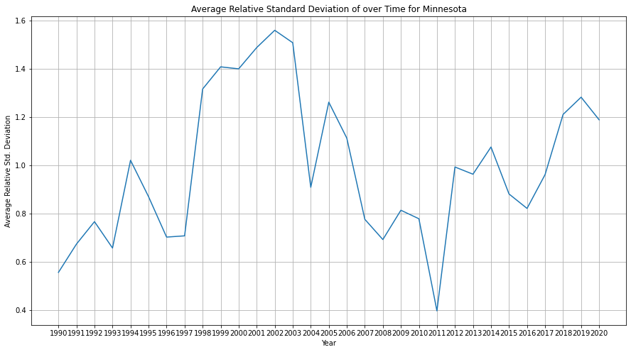

```python
plotRsdOverTime(df5, "Minnesota")
```

## Relating Wins to Distribution of Salaries top

How can we measure correlation? Before answering this we must need know if the data follows a normal distribution as explained in [Jason Brownlee's article on Machine Learning Master](https://machinelearningmastery.com/a-gentle-introduction-to-normality-tests-in-python/). If it does, we can use something like the Pearson correlation coefficient to test for a linear correlation, otherwise we will need to find a different coefficient, such as [Spearman's correlation coefficient](https://docs.scipy.org/doc/scipy/reference/generated/scipy.stats.spearmanr.html#scipy.stats.spearmanr).

In order to determine if the distribution is normal, we can start by plotting the win percentages and relative standard deviation in a histogram and check them visually.

But before doing this we will need to drop the last year from our dataframe because the win percentages are from a very small sample size of games. This is not a problem for salaries, which are finalized before the season starts, but win percentage data might be very skewed since only a few games have been played at the time of writing this.

```python
df6 = df5.drop('2020-2021')
df6.tail()
```

| year | team | salary rsd | win percentage |
| --- | --- | --- | --- |
| 2019-2020 | Sacramento | 0.954650 | 0.431 |
|  | San Antonio | 1.265622 | 0.451 |
|  | Toronto | 1.374404 | 0.736 |
|  | Utah | 1.350119 | 0.611 |
|  | Washington | 1.491647 | 0.347 |

Now we can visualize how win percentages and relative standard deviations are distributed.

```python
def plotHist(df, column, bins=None, range=None):
    plt.rcParams['figure.figsize'] = [8, 6]
    plt.hist(df[column], bins, range)
    plt.title(f"Distribution of {column}")
    plt.show()
```

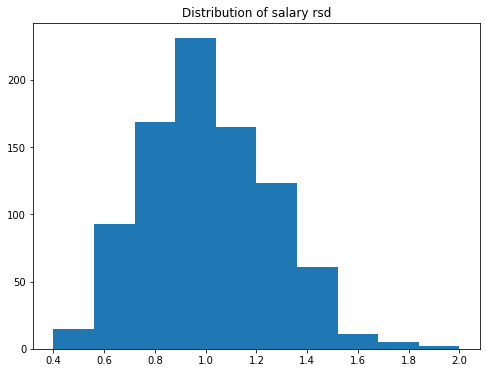

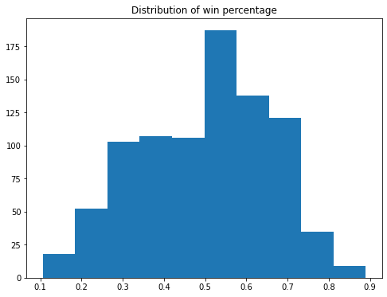

```python
plotHist(df6, 'salary rsd', 10, (0.4, 2.0))
plotHist(df6, 'win percentage')
```

These look roughly normal.

Although our visual check roughly confirms these are a normal distribution, we could use something more quantitative such as the shapiro-Wilk test. We can check the resulting p value to determine if the data likely comes from a normal distribution. A p value of 0.05 means that we cannot reject the hypothesis that the sample data comes from a population with a normal distribution. (https://en.wikipedia.org/wiki/Shapiro%E2%80%93Wilk_test)

```python
def printShapiroResults(df, column):
    a = 0.05
    stat, p = shapiro(df[column])
    print(stat, p, f"Passed: {p < a}")
```

```python
printShapiroResults(df6, "salary rsd")
printShapiroResults(df6, "win percentage")
```

```
0.9893555045127869 5.5933251132955775e-06 Passed: True
0.9847343564033508 6.427324450442029e-08 Passed: True
```

## Correlation of Win Percentage and Relative Standard Deviation top

Pearson's correlation coefficient is a number between -1 and 1 that represents the linear correlation between two datasets. -1 represents high negative correlation, 0 represents no linear correlation, and 1 represents a high positive correlation. The `scipy` package returns this value as well as the p value, which is the probability that the observed coefficient could have occurred in a random sample.

*Note: Following cell must be run twice in some circumstances. Output will usually be 'nan nan' the first time it is run.*

```python
correlation, p = pearsonr(df6['salary rsd'], df6['win percentage'])
print(correlation, p)
```

```
0.14766427295143592 1.142398358868267e-05
```

```python
def plotWinRsd(winp, rsd):
    plt.rcParams['figure.figsize'] = [8, 8]
    plt.scatter(winp, rsd)
    step = df6['salary rsd'].max() / 20 # 5% of high
    plt.axis(xmin=0, xmax=1,
             ymin=df6['salary rsd'].min() - step,
             ymax=df6['salary rsd'].max() + step)
    plt.title("Win Percentage vs. Relative Standard Deviation")
    plt.xlabel("Win Percentage")
    plt.ylabel("Relative Standard Deviation")
    plt.show
```

### Observed Data top

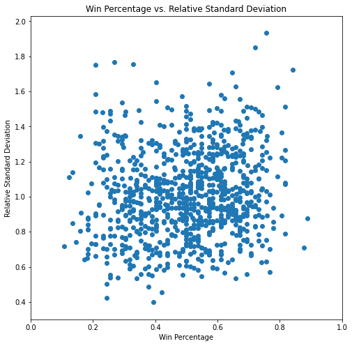

```python
plotWinRsd(df6['win percentage'], df6['salary rsd'])
```

### Random Data top

```python
def get_truncated_normal(mean=0, sd=1, low=0, upp=10):
    return truncnorm(
        (low - mean) / sd, (upp - mean) / sd, loc=mean, scale=sd)

def randSeriesFrom(series):
    randSeries = get_truncated_normal(mean=series.mean(),
                               sd=series.std(),
                               low=series.min(),
                               upp=series.max())

    return randSeries.rvs(series.size)
```

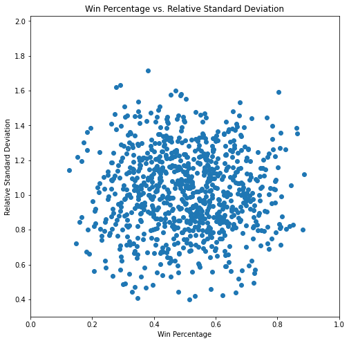

```python
randWinP = randSeriesFrom(df6['win percentage'])
randRsd = randSeriesFrom(df6['salary rsd'])
plotWinRsd(randWinP, randRsd)
```

*Note: Following cell must be run twice in some circumstances. Output will be 'nan nan' the first time it's run after the proceeding cell is run.*

```python
correlation, p = pearsonr(randRsd, randWinP)
print(correlation, p)
```

```
-0.006658970577852621 0.84397755882838
```

The correlation coefficient is lower (-0.007 to 3 d.p.) compared to our observed data (0.148 to 3 d.p.) and the p value is higher (0.844 to 3 d.p.) than the observed data (0.000011) as well. This means there is even less linear correlation than our dataset and the probability that it was generated randomly is high. This is somewhat evident in the shape of the plot. We see a circle with with a dense center and limits that are pretty even in their distance from the core. This illustrates how our normally distributed data is different than a random normal distribution.

## Further Exploration top

I am curious if looking at the extremes for either variables will reveal any patterns. That is, if we take the top 10 percentile teams by wins for each year, will we notice anything about the distribution of relative standard deviations? This question can also be asked about the bottom 10 percentile team by wins, as well as the top/bottom 10 percentile team by relative standard deviation.

To get the top and bottom percentile teams we can sort by win percentage, group by year, and then take the first/last 3 teams (roughly 30 teams each year).

```python
df7 = df6.sort_values("win percentage").groupby("year", as_index=False).head(3)
df8 = df6.sort_values("win percentage").groupby("year", as_index=False).tail(3)
```

For example, we can get the bottom 3 teams by winning percentage from 1990-1991 like so:

```python
df7.loc["1990-1991"]
```

| team | salary rsd | win percentage |
| --- | --- | --- |
| Denver | 0.702283 | 0.244 |
| Miami | 0.927880 | 0.293 |
| Sacramento | 0.947356 | 0.305 |

Now we can plot them. The orange dots are the top 10 percentile by win percentage and the blue dots are the bottom 10 percentile.

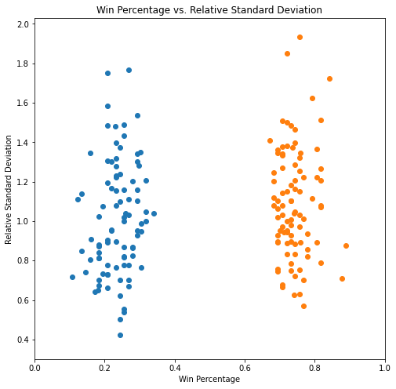

```python
plotWinRsd(df7['win percentage'], df7['salary rsd']) #bottom 10 percentile
plotWinRsd(df8['win percentage'], df8['salary rsd']) #top 10 percentile
```

This doesn't tell us too much. The top 10 percentile by wins seem to have a few more extreme high relative standard deviations, and the bottom 10 percentile seems to have a few more extreme lows, but these amounts are probably insignificant. Other than these extremes, it seems the cluster on the right (top 10 percentile) are clustered a bit tighter than the left side (bottom 10 percentile).

Since we already know we're dealing with the highest and lowest winning teams, it's of limited value to plot the win percentage dimension. We can ignore this axis and just plot the distribution of relative standard deviations in a histogram for both the top and bottom 10 percentile.

This draws from the bottom 10 percentile of teams for each year and shows the distribution of salaries amongst them.

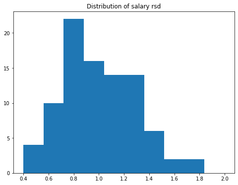

```python
plotHist(df7, 'salary rsd', 10, (0.4, 2.0))
```

This draws from the top 10 percentile of teams for each year and shows the distribution of salaries amongst them.

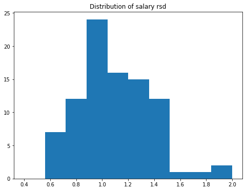

```python
plotHist(df8, 'salary rsd', 10, (0.4, 2.0))
```

We see the extreme ends differ and the top 10 percentile is a little less spread out, as we noted from the scatterplot, but the histograms don't reveal much else of note.

Similarly, we can look at the top/bottom 10 percentile of teams per year by the relative standard deviation. This time we just need to sort by `salary rsd` before applying the saming grouping.

```python
df9 = df6.sort_values("salary rsd").groupby("year", as_index=False).head(3)
df10 = df6.sort_values("salary rsd").groupby("year", as_index=False).tail(3)
```

So we can get the top 10 percentile of relative standard devations for the most recently completed season like so:

```python
df10.loc["2019-2020"]
```

| team | salary rsd | win percentage |
| --- | --- | --- |
| Washington | 1.491647 | 0.347 |
| Brooklyn | 1.570608 | 0.486 |
| Houston | 1.580495 | 0.611 |

Now let's plot all of them. The orange dots are the top 10 percentile by relative standard deviation and the blue dots are the bottom 10 percentile.

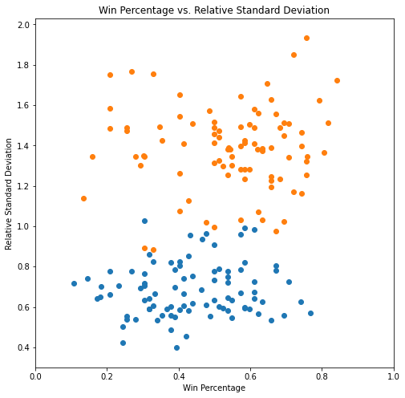

```python
plotWinRsd(df9['win percentage'], df9['salary rsd']) #bottom 10 percentile
plotWinRsd(df10['win percentage'], df10['salary rsd']) #top 10 percentile
```

What we care about here is horizontal dimmension. We see the overall range is pretty looks pretty similar. One of the more interesting things to note is that there is crossover between the top and bottom percentiles. That is, some years' teams with the lowest relative standard deviation were higher than the teams with the highest relative standard deviations. This probably shouldn't suprise us too much since we learned earlier that the average relative standard deviation per year has been on the rise.

We can look at the histogram for these percentiles as well. This first histogram shows win percentages for the bottom 10 percentile teams per year by relative standard deviation.

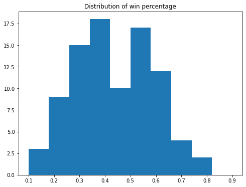

```python
plotHist(df9, 'win percentage', 10, (0.1, 0.9))
```

This is a fairly normal looking distribution with similar extremes and most win perventages falling in the middle.

Now lets look at the top 10 percentile of teams per year by relative standard deviation.

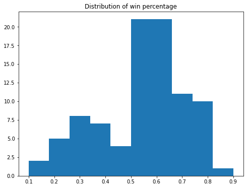

```python
plotHist(df10, 'win percentage', 10, (0.1, 0.9))
```

This one is more interesting - we see that the teams who have more disparite salaries than other teams in the league that year perform better than the average team. The average win percentage is extremely close since teams normally play the same number of games, and a win for 1 team means loss for the other. We can see this here:

```python
df5["win percentage"].mean()
```

```
0.49961589403973516
```

## Measuring Correlation Over Time top

So far we have aggregated all win and relative standard deviation data and tried to identify a correlatoin. Since we saw that the relative standard deviation has trended upward over time, it's possible the correlation coefficient has change as well. Perhaps there is a clear trend in one direction or another. This will answer the last of our more open-ended questions I posed at the beginning: **Has this strategy's effectiveness been consistent or changed over time?**

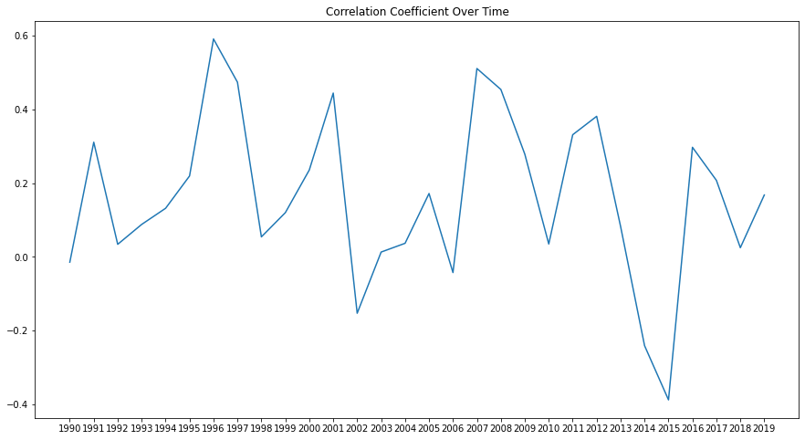

```python
df11 = df6.groupby('year')['salary rsd'].corr(df6['win percentage'])
plt.rcParams['figure.figsize'] = [15, 8]
years = [x.split("-")[0] for x in df11.index]
plt.plot(years, df11.values)
plt.title("Correlation Coefficient Over Time")
plt.show()
```

The graph shows that the coefficient has bounced around over time (ranging from ~0.6 to ~-0.4) but appears to trend around the ~0.15 coefficient we saw in aggregate. It does not appear to trend one way or another.

We can pick out the most extreme years in either direction to see what they look like graphed with a linear regression line.

```python
def plotScatterLine(df, year):
    x = df.loc[(year)]['win percentage']
    y = df.loc[(year)]['salary rsd']
    plotWinRsd(x, y)
    res = linregress(x, y)
    plt.plot(x, res.intercept + res.slope*x, 'r', label='fitted line')
```

First, the lowest correlation which occurred inin 2015-2016: ~-0.4

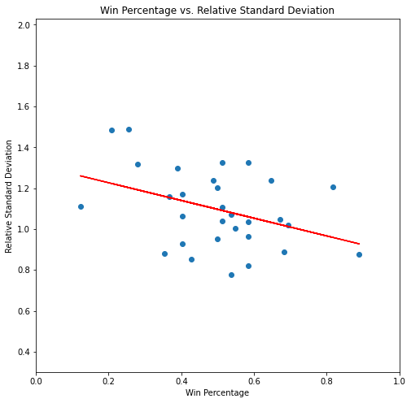

```python
plotScatterLine(df6, '2015-2016')
```

Next, the highest correlation which occurred in 1996-1997: ~0.6

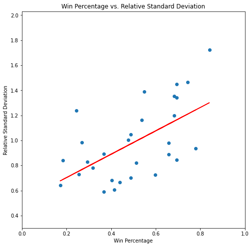

```python
plotScatterLine(df6, '1996-1997')
```

# Conclusions top

### Results top

To recap, we hypothesized that salaries have become less evenly distributed over time, and that this trend started around the time Lebron moved to the Heat. Both of these were proven true, and we also learned that a similar upward trend occured in the mid 90's.

We did not get a definitive answer for how the uneven distribution of salaries correlates to success. We saw that the teams with the most disparite salaries each year did better than average, but there was not a linear correlation overall.

### Suggestions for future direction top

In the Washington Post article entitled ["Big Threes are out, Big Twos are in, and the NBA is the most balanced it’s been in years"](https://www.washingtonpost.com/sports/2019/10/21/big-threes-are-out-big-twos-are-nba-is-most-balanced-its-been-years/), Ben Golliver suggests that we are moving away from on "Big Threes" to "Big Twos". It would be interesting to test this claim with the data that we have. This also suggests that we may be able to measure the allocation of salaries differently. Instead of using the relative standard deviation we could use the percentage allocated to n-players (such as 2, or 3). This could be measured over time and correlated to win percentage like we did with the relative standard deviations.

We could also try to measure success differently. While regular season win percentage should be a fairly good indicator, it's not the best way to determine who is the very best team. Often teams will hold back in the regular season in anticipation of the playoffs. With 7 game playoff series, the best teams nearly always advance. The API I used does not have this information readily available but parsing playoff game history to determine final rankings might be worth it to give us another perspective on success.

### What I would do differently top

One thing I would do differently is the storage of the data I collected. Originally JSON made sense to me because of how I thought about the data: Every year has teams, and each of these teams has players, and players have salaries. This is how I arrived at the nested structure. I also wasn't nearly as familiar with pandas as I am now. If I were to start over I would use a csv file instead which would flatten all my data out like so:

```
year, team, player, salary, winpct
year1, team1, player1, s1, w1
year1, team1, player2, s2, w1
```

Then I could more easily load it into a pandas dataframe and use `groupby()` and `MultiIndex` to deal with the different levels like I had to do anyways.

# Appendix top

## Data sources top

- https://hoopshype.com/salaries/ for team, player, and salary records
- An unofficial API for https://www.nba.com/stats/, maintained here https://github.com/swar/nba_api

## Git history top

I used git and github for version control of this project. The git history can be seen here:

```python
!git log --oneline --decorate --graph --all
```

```
* 29bb867 (HEAD -> main, origin/main) added conclusion and appendix
* 3123431 requirements added
* d888703 updated data
* 2c49acf directory structure changes and refactor
* 06d0508 no longer holds rel std dev
* 35087a3 removed dirs during refactor
* c68259f major refactor
* bf5025d added soup backup
* b111794 added relStdDev and winPct
* 5b043b4 added details on sources
* 1a670f1 added file
* d1cbd24 changed file structure
* 0be867a added backup
* c38081a modularized and added more data and analysis
* f80ef0e init commit
```